# Analisa dan Prediksi COVID-19

Melakukan Analisa Menggunakan R dan Algoritma ML Prophet

Faris Dzikrur Rahman

2020-03-09

# Pendahuluan

Novel coronavirus atau yang sekarang dinamai COVID-19 adalah virus menular yang menyebabkan gangguan pada pernafasan. Virus ini telah diidentifikasikan sebagai agen utama merebaknya coronavirus di Wuhan pada tahun 2019-20 yang sampai hari ini terus terjadi.

Seperti yang terjadi pada beberapa kasus awal kemunculan penyakit ini yang dipekirakan terkait erat dengan adanya pasar hewan laut dan hewan lainnya yang cukup besar, virus ini disinyalir memiliki akar dari hewan-hewan tersebut, namun hal ini belum dapat dikonfirmasi. Ketika dibandingkan, susunan genetika dari virus ini ternyata memiliki kemiripan dengan virus semisal SARS-CoV (79.5%) dan bat coronaviruses (96%), yang membuat virus ini sangat mungkin berasal dari kelelawar.

Kasus pertama pada manusia terjadi pada 8 Desember 2019. Wabah COVID-19 terdeteksi pertama kali di Wuhan, China, pada pertengahan Desember 2019. Virus ini kemudian menyebar ke seluruh provinsi di Cina dan ke lebih dari 20 negara lainnya di Asia, Eropa, Amerika Utara, dan Oseania. Penularan virus dari manusia ke manusia pertama kali telah dikonfirmasi terjadi di Cina, Jerman, Thailand, Taiwan, Jepang, dan Amerika Serikat, dan sekarang penularan ini sudah semakin masif dan hampir keseluruhannya merupakan dari manusia ke manusia, termasuk pula yang terjadi pada Italia dan Iran.

Per 4 Maret 2020, dimana artikel ini ditulis, 95000 lebih orang telah dinyatakan positif COVID-19, dimana sebagian besarnya berada di Cina. Kasus yang terjadi di luar Cina, sampai saat ini adalah mereka yang baru saja pulang dari Wuhan, atau berinteraksi dengan orang-orang yang baru saja ke Wuhan. Jumlah kematian hingga 4 Maret 2020 ini adalah sejumlah 3000 lebih orang.

Setelah merebaknya kasus ini, sudah banyak data-data statistik mengenai kasus ini yang dibuka untuk publik, salah satunya adalah yang dirilis oleh John Hopkins University, yang merupakan data kasus COVID-19 di seluruh negara yang direkam per hari.

Data ini akan dianalisa menggunakan software R, dengan memanfaatkan framework tidyverse, yang mencakup library-library untuk memudahkan proses data cleaning, data munging, visualisasi, dan modeling.

Hal pertama yang akan kita lakukan adalah meng-import library dan package yang akan digunakan pada laporan ini.

```r
library(tidyverse)

library(data.table)

library(bbplot)
```

Sebelum melakukan analisa data secara eksploratif, kita wajib mengetahui karakteristik data kita. Dari penelusuran di bawah, diketahui bahwa ada kolom yang masih belum sesuai tipe datanya dengan yang seharusnya, sehingga harus dirubah agar memudahkan analisa. Salah satunya adalah kolom Date yang masih bertipe character, sehingga harus dirubah menjadi tipe date time.

```r
covid <- read_csv("corona-virus-report (1)/covid_19_clean_complete.csv")
conf_rw <- read_csv("novel-corona-virus-2019-dataset (2)/COVID19_line_list_data.csv")
str(covid)
```

```
## Classes 'spec_tbl_df', 'tbl_df', 'tbl' and 'data.frame': 6880 obs. of  8 variables:
##  $ Province/State: chr  "Anhui" "Beijing" "Chongqing" "Fujian" ...
##  $ Country/Region: chr  "Mainland China" "Mainland China" "Mainland China" "Mainland China" ...
##  $ Lat           : num  31.8 40.2 30.1 26.1 36.1 ...
##  $ Long          : num  117 116 108 118 104 ...
##  $ Date          : chr  "1/22/20" "1/22/20" "1/22/20" "1/22/20" ...
##  $ Confirmed     : num  1 14 6 1 0 26 2 1 4 1 ...
##  $ Deaths        : num  0 0 0 0 0 0 0 0 0 0 ...
##  $ Recovered     : num  0 0 0 0 0 0 0 0 0 0 ...
##  - attr(*, "spec")=
##   .. cols(
##   ..   `Province/State` = col_character(),
##   ..   `Country/Region` = col_character(),
##   ..   Lat = col_double(),
##   ..   Long = col_double(),
##   ..   Date = col_character(),
##   ..   Confirmed = col_double(),
##   ..   Deaths = col_double(),
##   ..   Recovered = col_double()
##   .. )
```

Penamaan kolom sangatlah penting sehingga penamaan kolom diganti dengan yang lebih pendek dan sederhana.

```r
covid <- covid %>% rename(STATE = `Province/State`, COUNTRY = `Country/Region`, LAT = Lat, LONG = Long, DATE = Date, CONFIRMED = Confirmed, DEATH = Deaths, RECOVERED = Recovered)

covid
```

```
## # A tibble: 6,880 x 8
##    STATE     COUNTRY          LAT  LONG DATE    CONFIRMED DEATH RECOVERED
##    <chr>     <chr>          <dbl> <dbl> <chr>       <dbl> <dbl>     <dbl>
##  1 Anhui     Mainland China  31.8  117. 1/22/20         1     0         0
##  2 Beijing   Mainland China  40.2  116. 1/22/20        14     0         0
##  3 Chongqing Mainland China  30.1  108. 1/22/20         6     0         0
##  4 Fujian    Mainland China  26.1  118. 1/22/20         1     0         0
##  5 Gansu     Mainland China  36.1  104. 1/22/20         0     0         0
##  6 Guangdong Mainland China  23.3  113. 1/22/20        26     0         0
##  7 Guangxi   Mainland China  23.8  109. 1/22/20         2     0         0
##  8 Guizhou   Mainland China  26.8  107. 1/22/20         1     0         0
##  9 Hainan    Mainland China  19.2  110. 1/22/20         4     0         0
## 10 Hebei     Mainland China  38.0  115. 1/22/20         1     0         0
## # ... with 6,870 more rows
```

Kolom tanggal dengan format character/string akan kita ganti dengan datetime

```r
covid$DATE <- as.Date(covid$DATE, format = "%m/%d/%y")

covid
```

```
## # A tibble: 6,880 x 8
##    STATE     COUNTRY          LAT  LONG DATE       CONFIRMED DEATH RECOVERED
##    <chr>     <chr>          <dbl> <dbl> <date>         <dbl> <dbl>     <dbl>
##  1 Anhui     Mainland China  31.8  117. 2020-01-22         1     0         0
##  2 Beijing   Mainland China  40.2  116. 2020-01-22        14     0         0
##  3 Chongqing Mainland China  30.1  108. 2020-01-22         6     0         0
##  4 Fujian    Mainland China  26.1  118. 2020-01-22         1     0         0
##  5 Gansu     Mainland China  36.1  104. 2020-01-22         0     0         0
##  6 Guangdong Mainland China  23.3  113. 2020-01-22        26     0         0
##  7 Guangxi   Mainland China  23.8  109. 2020-01-22         2     0         0
##  8 Guizhou   Mainland China  26.8  107. 2020-01-22         1     0         0
##  9 Hainan    Mainland China  19.2  110. 2020-01-22         4     0         0
## 10 Hebei     Mainland China  38.0  115. 2020-01-22         1     0         0
## # ... with 6,870 more rows
```

Setelah melakukan data cleaning, kita akan mulai mengeksplorasi data untuk mengetahui trend dan kondisi terkini dari virus yang sangat mewabah ini.

```r
summary_all <- covid %>% group_by(DATE) %>% summarize(CONFIRMED=sum(CONFIRMED), DEATH=sum(DEATH),RECOVERED=sum(RECOVERED))

summary <- summary_all %>% arrange(desc(DATE))

head(summary, 1)
```

```
## # A tibble: 1 x 4
##   DATE       CONFIRMED DEATH RECOVERED
##   <date>         <dbl> <dbl>     <dbl>
## 1 2020-03-04     95124  3254     51171
```

# Exploratory Data Analysis

Hal pertama yang akan kita analisa adalah perbandingan angka positif, angka kematian, dan angka kesembuhan dari masing-masing negara. Namun, kita akan mengelompokkan negara-negara ini menjadi tiga kelompok, yaitu ‘Hubei’, dimana merupakan provinsi di Cina dengan kasus positif tertinggi, ‘provinsi Cina lainnya’, dan negara lain selain Cina. Namun pada tabel belum ada kolom yang mengelompokkan ketiganya sehingga kita akan membuat fungsi untuk memisahkan country dan state menjadi tiga kelompok.

```r
location_df <- function(row) {
  if (row["COUNTRY"] == "Mainland China") {
    if (row["STATE"] == "Hubei") {
      return("Hubei")
    } else {
      return("Other Chinese Provinces")
    }
  } else {
    return("Rest of the World")
  }
}
```

Untuk menjaga data covid agar tidak berubah, maka kita akan meng-assign variabel baru yang akan kita rubah untuk analisa.

```r
temp <- covid
```

Buat kolom baru bernama ‘SEGMENT’ dengan mengaplikasikan fungsi yang sudah kita buat pada data frame.

```r
temp["SEGMENT"] <- apply(temp, 1, location_df) #1, apply func by row -- 2, apply func by cols

temp
```

```
## # A tibble: 6,880 x 9
##    STATE   COUNTRY    LAT  LONG DATE       CONFIRMED DEATH RECOVERED SEGMENT
##    <chr>   <chr>    <dbl> <dbl> <date>         <dbl> <dbl>     <dbl> <chr>
##  1 Anhui   Mainlan~  31.8  117. 2020-01-22         1     0         0 Other Chin~
##  2 Beijing Mainlan~  40.2  116. 2020-01-22        14     0         0 Other Chin~
##  3 Chongq~ Mainlan~  30.1  108. 2020-01-22         6     0         0 Other Chin~
##  4 Fujian  Mainlan~  26.1  118. 2020-01-22         1     0         0 Other Chin~
##  5 Gansu   Mainlan~  36.1  104. 2020-01-22         0     0         0 Other Chin~
##  6 Guangd~ Mainlan~  23.3  113. 2020-01-22        26     0         0 Other Chin~
##  7 Guangxi Mainlan~  23.8  109. 2020-01-22         2     0         0 Other Chin~
##  8 Guizhou Mainlan~  26.8  107. 2020-01-22         1     0         0 Other Chin~
##  9 Hainan  Mainlan~  19.2  110. 2020-01-22         4     0         0 Other Chin~
## 10 Hebei   Mainlan~  38.0  115. 2020-01-22         1     0         0 Other Chin~
## # ... with 6,870 more rows
```

## Visualisasi Positif COVID-19

Sebelum melakukan visualisasi, kita akan mempersiapkan tabel yang dikelompokkan berdasarkan tanggal / per hari sehingga kita dapat mengetahui trend harian.

```r
temp_conf <- temp %>% group_by(DATE,SEGMENT) %>% summarize(CONFIRMED=sum(CONFIRMED))

temp_conf
```

```
## # A tibble: 129 x 3
## # Groups:   DATE [43]
##    DATE       SEGMENT                 CONFIRMED
##    <date>     <chr>                       <dbl>
##  1 2020-01-22 Hubei                         444
##  2 2020-01-22 Other Chinese Provinces       103
##  3 2020-01-22 Rest of the World               8
##  4 2020-01-23 Hubei                         444
##  5 2020-01-23 Other Chinese Provinces       195
##  6 2020-01-23 Rest of the World              14
##  7 2020-01-24 Hubei                         549
##  8 2020-01-24 Other Chinese Provinces       367
##  9 2020-01-24 Rest of the World              25
## 10 2020-01-25 Hubei                         761
## # ... with 119 more rows
```

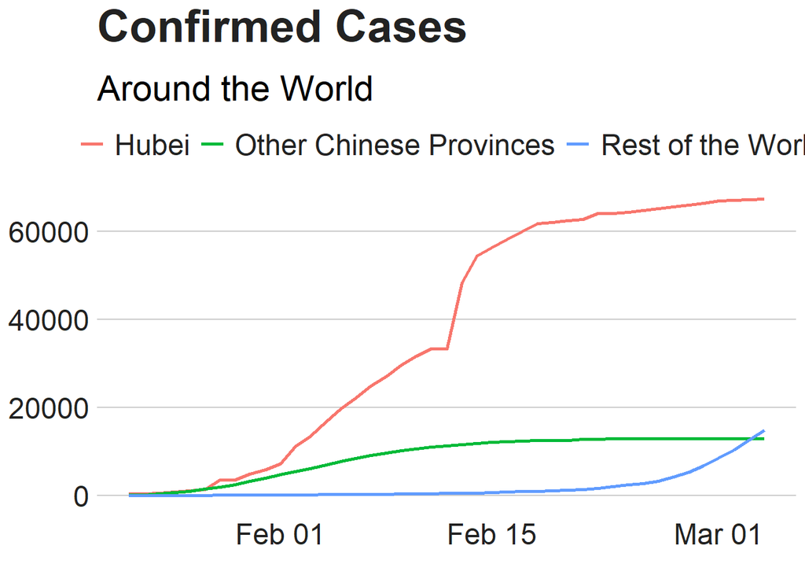

```r
plot_conf <- ggplot(temp_conf, aes(x=DATE, y=CONFIRMED, color=SEGMENT)) +
  geom_line(size=1) +
  labs(x = "",
       y = "Confirm Case",
       title = "Confirmed Cases",
       subtitle = "Around the World") +
  bbc_style()

plot_conf
```

## Visualisasi Kematian COVID-19

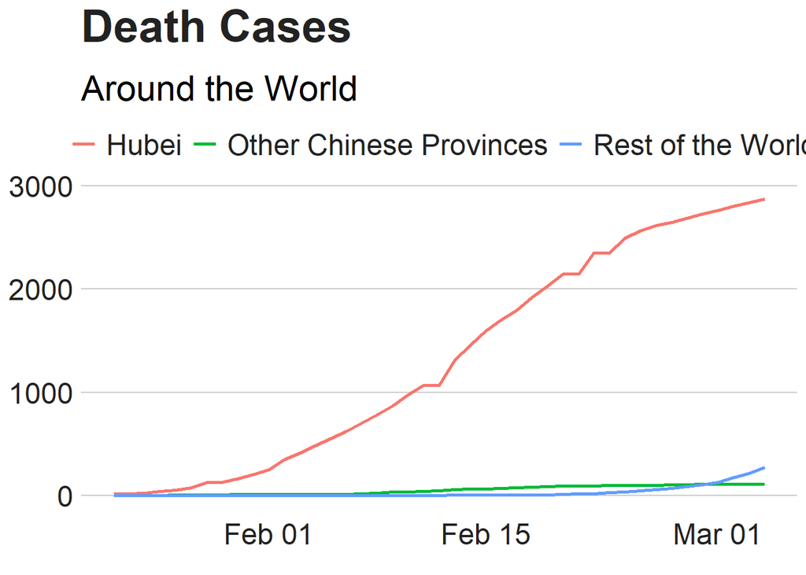

```r
temp_death <- temp %>% group_by(DATE,SEGMENT) %>% summarize(DEATH=sum(DEATH))

plot_death <- ggplot(temp_death, aes(x=DATE, y=DEATH, color=SEGMENT)) +
  geom_line(size=1) +
   labs(x = "",
       y = "Death Cases",
       title = "Death Cases",
       subtitle = "Around the World") +
  bbc_style()

plot_death
```

# Visualisasi Angka Kesembuhan COVID-19

Meskipun Hubei merupakan provinsi di Cina dengan angka positif dan kematian tertinggi dan terus meningkat, namun hal ini juga diimbangi dengan angka kesembuhan yang juga tinggi dan semakin meningkat. Peningkatan ini juga dialami oleh provinsi di luar Hubei. Negara-negara selain Cina masih tampak stagnan angka kesembuhannya meskipun sudah mulai ada kecenderungan sedikit naik. Hal ini mungkin juga disebabkan karena Coronavirus baru merebak sekitar beberapa hari sehingga membutuhkan waktu yang lebih lama untuk dapat sembuh. Pemantauan harus dilakukan beberapa hari ke depan untuk melihat angka kesembuhannya.

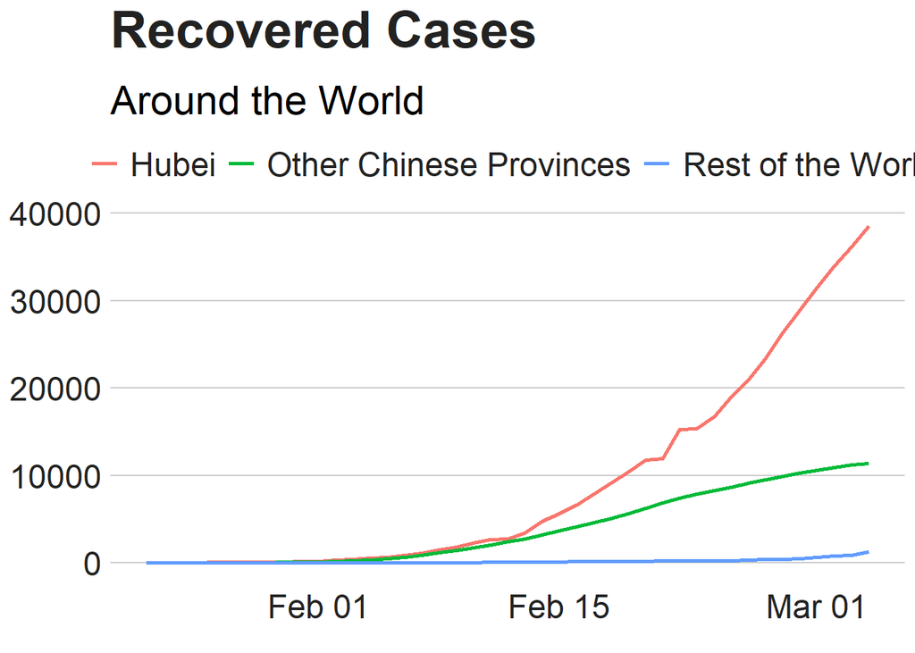

```r
temp_rec <- temp %>% group_by(DATE,SEGMENT) %>% summarize(RECOVERED=sum(RECOVERED))

plot_rec <- ggplot(temp_rec, aes(x=DATE, y=RECOVERED, color=SEGMENT)) +
  geom_line(size=1) +
   labs(x = "",
       y = "Recovered Cases",
       title = "Recovered Cases",
       subtitle = "Around the World") +
  bbc_style()

plot_rec
```

Agar kita dapat mengetahui angka kematian dan kesembuhan dengan lebih baik tanpa ada bias dikarenakan jumlah penduduk yang berbeda-beda di masing-masing tiga kelompok negara, maka kita akan melakukan visualisasi rasio kematian dan kesembuhan dengan membaginya dengan angka yang terkonfirmasi positif COVID-19.

# Rasio Kematian

Untuk melakukan visualisasi rasio kematian, kita membutuhkan kolom tambahan yang akan kita isi dengan nilai rasio kematian, yaitu persentase angka kematian dan angka positif.

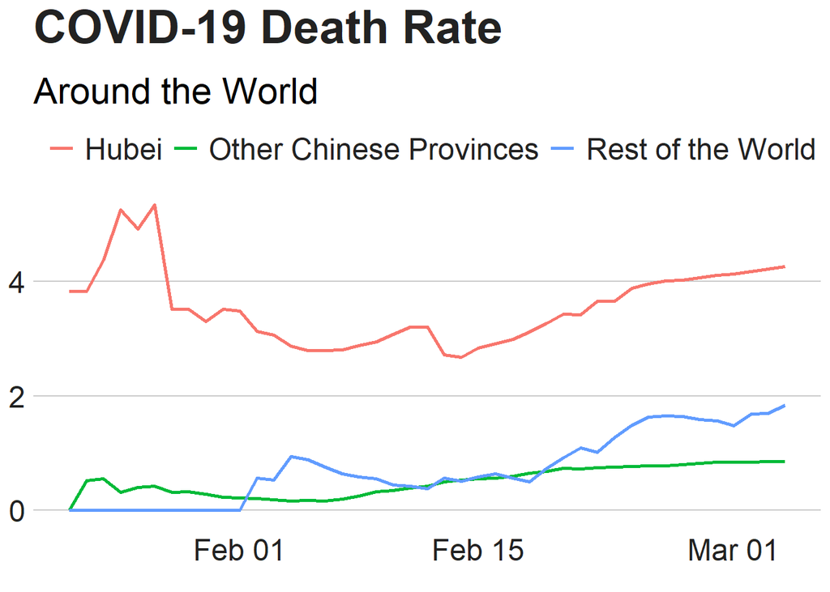

```r
temp_death_conf <- temp %>% group_by(DATE, SEGMENT) %>% summarize(DEATH=sum(DEATH),CONFIRMED=sum(CONFIRMED))

temp_death_rate <- temp_death_conf %>% mutate(DEATHRATE = 100*(DEATH / CONFIRMED))

plot_death_rate <- ggplot(temp_death_rate, aes(x=DATE, y=DEATHRATE, color=SEGMENT)) +
  geom_line(size=1) +
   labs(x = "",
       y = "Rate",
       title = "COVID-19 Death Rate",
       subtitle = "Around the World") +
  bbc_style()

plot_death_rate
```

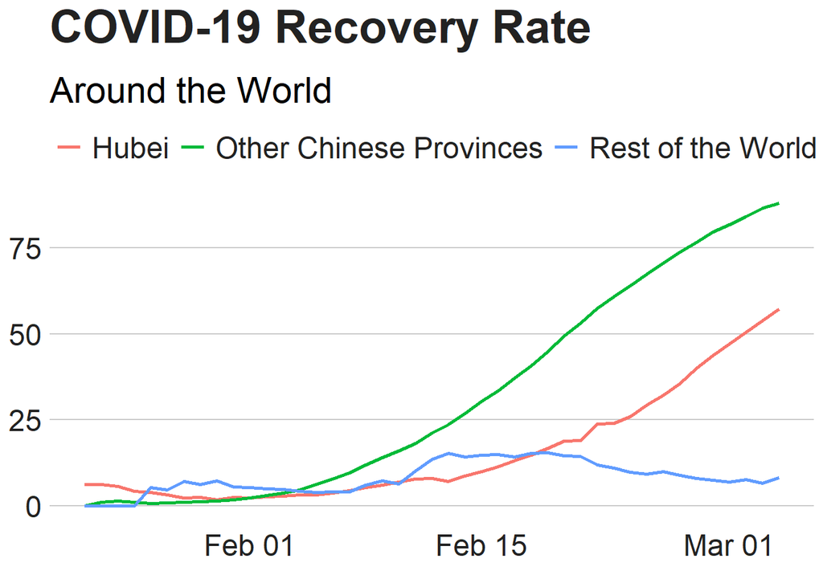

```r
temp_rec_conf <- temp %>% group_by(DATE, SEGMENT) %>% summarize(RECOVERED=sum(RECOVERED),CONFIRMED=sum(CONFIRMED))

temp_rec_rate <- temp_rec_conf %>% mutate(RECRATE = 100*(RECOVERED / CONFIRMED))

plot_rec_rate <- ggplot(temp_rec_rate, aes(x=DATE, y=RECRATE, color=SEGMENT)) +
  geom_line(size=1) +
   labs(x = "",
       y = "Rate",
       title = "COVID-19 Recovery Rate",
       subtitle = "Around the World") +
  bbc_style()

plot_rec_rate
```

Setelah kita mendapatkan insight melalui visualisasi dari data yang kita miliki, tahapan selanjutnya akan mengenai bagaimana dengan data harian ini, kita dapat membuat forecast basic / dasar dengan menggunakan algoritma machine learning yang dibangun oleh Data Scientist Facebook yang diberi nama Prophet. Prophet bekerja dengan menggunakan data time series yang mereka klaim memiliki tingkat akurasi prediksi yang cukup tinggi.

# Forecast Menggunakan Algoritma Machine Learning Prophet

Untuk mengaplikasikan algoritma ini ke data yang kita miliki, kita menggunakan package “prophet”.

```r
# install.packages("prophet")

library(prophet)
```

## Menyiapkan Data

Selanjutnya, kita mempersiapkan data yang dibutuhkan untuk proses modeling. Prophet hanya membutuhkan dua nilai di dalam satu tabel data frame, yaitu kolom yang berisikan waktu/tanggal/hari dan kolom yang berisikan suatu value yang akan kita prediksi. Dalam hal ini kita ingin memprediksi angka positif dalam sebulan ke depan. Maka kita mengisi kolom tersebut dengan angka positif dari data harian yang kita miliki. Dikarenakan Prophet hanya menerima kolom dengan nama “ds” dan “y”, maka kita harus mengganti nama kolom yang kita miliki. “ds” berisikan waktu, sedangkan “y” berisikan value / nilai.

```r
temp_prophet <- temp %>% group_by(DATE) %>%  summarize(CONFIRMED=sum(CONFIRMED))
temp_prophet <- temp_prophet %>% rename(ds = DATE, y = CONFIRMED)
temp_prophet_death <- temp %>% group_by(DATE) %>%  summarize(DEATH=sum(DEATH))
temp_prophet_death <- temp_prophet_death %>% rename(ds = DATE, y = DEATH)

temp_prophet
```

```
## # A tibble: 43 x 2
##    ds             y
##    <date>     <dbl>
##  1 2020-01-22   555
##  2 2020-01-23   653
##  3 2020-01-24   941
##  4 2020-01-25  1434
##  5 2020-01-26  2118
##  6 2020-01-27  2927
##  7 2020-01-28  5578
##  8 2020-01-29  6166
##  9 2020-01-30  8234
## 10 2020-01-31  9927
## # ... with 33 more rows
```

```r
temp_prophet_death
```

```
## # A tibble: 43 x 2
##    ds             y
##    <date>     <dbl>
##  1 2020-01-22    17
##  2 2020-01-23    18
##  3 2020-01-24    26
##  4 2020-01-25    42
##  5 2020-01-26    56
##  6 2020-01-27    82
##  7 2020-01-28   131
##  8 2020-01-29   133
##  9 2020-01-30   171
## 10 2020-01-31   213
## # ... with 33 more rows
```

## Membuat Model

### Prediksi Positif COVID-19

Setelah data yang berisikan dua kolom, “ds” dan “y” siap, kita akan mulai membuat model.

Pertama, kita membuat instance dengan variabel “m”

```r
m <- prophet(temp_prophet)
```

```
## Disabling yearly seasonality. Run prophet with yearly.seasonality=TRUE to override this.
```

```
## Disabling daily seasonality. Run prophet with daily.seasonality=TRUE to override this.
```

Setelah itu, kita membuat dataframe baru yang menampung nilai masa depan / nilai prediksi, dimana kali ini kita prediksi 1 bulan ke depan, artinya kita isi periode selama 30 hari. Disini kita gunakan function yang sudah tersedia pada library prophet yaitu `make_future_dataframe()`.

```r
future <- make_future_dataframe(m, periods = 30)
tail(future)
```

```
##            ds
## 68 2020-03-29
## 69 2020-03-30
## 70 2020-03-31
## 71 2020-04-01
## 72 2020-04-02
## 73 2020-04-03
```

Selanjutnya, kita melakukan prediksi dengan `predict()` menggunakan data “m” dan data “future”.

```r
forecast <- predict(m, future)
```

Berikut ini adalah nilai akhir dari prediksi yang kita lakukan, yaitu 30 hari setelah data terakhir yang kita miliki.

```r
forecasted_conf <- forecast %>%
  arrange(desc(ds)) %>%
  slice(1) %>%
  pull(yhat) %>%
  round()

forecasted_conf
```

```
## [1] 157852
```

Visualisasi juga perlu dilakukan agar hasil prediksi dapat terlihat dengan jelas.

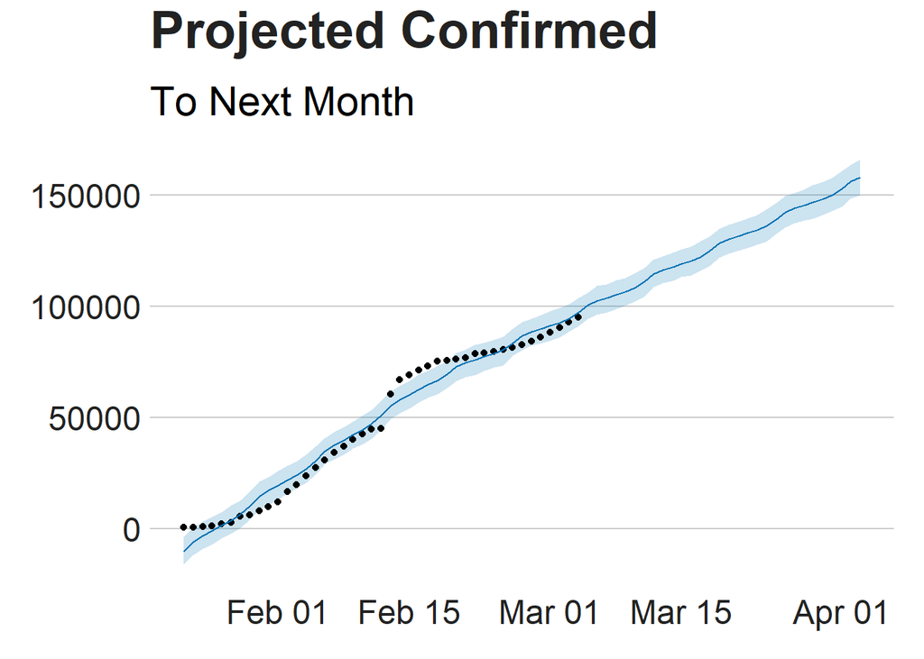

```r
forecast_p <- plot(m, forecast) +
  labs(x = "",
       y = "confirmed case",
       title = "Projected Confirmed",
       subtitle = "To Next Month") + bbc_style()

forecast_p
```

Dari hasil prediksi tersebut, kita dapat melihat bahwa jika trend ini terus meningkat, angka positif terjangkit COVID-19 dapat meningkat hingga 150.000 jiwa di bulan April. Namun, tentunya dikarenakan data historis yang kita miliki sangat sedikit, ini tidak bisa dijadikan acuan pasti. Untuk memprediksi masa depan, kita harus memiliki data historis yang mencukupi.

### Prediksi Angka Kematian COVID-19

Kita juga akan memprediksi angka kematian COVID-19 dalam sebulan ke depan, yaitu 30 hari.

Pertama, buat instance “m_death” dengan fungsi `prophet()`

```r
m_death <- prophet(temp_prophet_death)
```

```
## Disabling yearly seasonality. Run prophet with yearly.seasonality=TRUE to override this.
```

```
## Disabling daily seasonality. Run prophet with daily.seasonality=TRUE to override this.
```

Setelah itu, buat tabel baru berisikan nilai prediksi masa depan selama 30 hari ke depan.

```r
future_death <- make_future_dataframe(m_death, periods = 30)
tail(future_death)
```

```
##            ds
## 68 2020-03-29
## 69 2020-03-30
## 70 2020-03-31
## 71 2020-04-01
## 72 2020-04-02
## 73 2020-04-03
```

Prediksi dilakukan menggunakan instance “m_death” dan dataframe “future_death”.

```r
forecast_death <- predict(m_death, future_death)
```

Berikut adalah angka prediksi kematian setelah 30 hari.

```r
forecasted_death <- forecast_death %>%
  arrange(desc(ds)) %>%
  slice(1) %>%
  pull(yhat) %>%
  round()

forecasted_death
```

```
## [1] 5343
```

Untuk dapat melihat trendnya dengan jelas, kita lakukan visualisasi data tersebut.

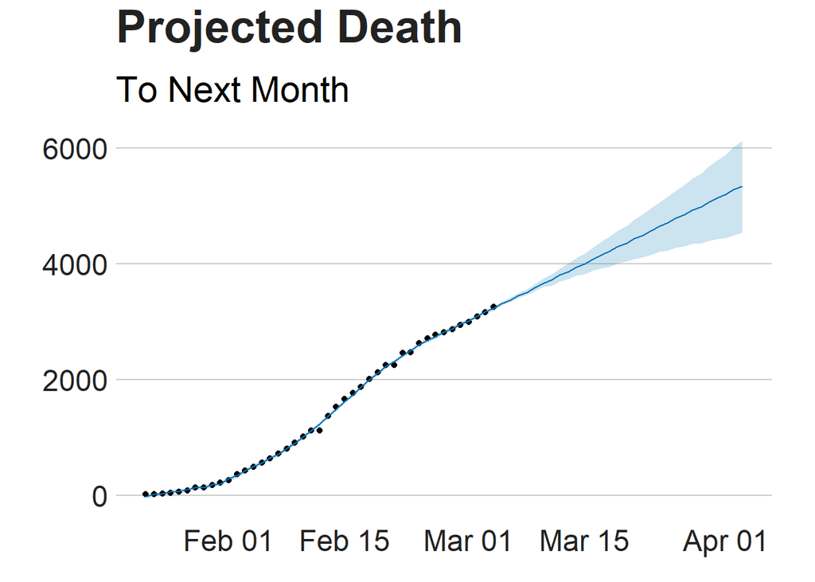

```r
forecast_p_death <- plot(m_death, forecast_death) +
  labs(x = "",
       y = "death case",
       title = "Projected Death",
       subtitle = "To Next Month") + bbc_style()

forecast_p_death
```

Dapat terlihat dari visualisasi tersebut bahwa angka kematian juga akan semakin meningkat selama 30 hari ke depan dikarenakan trend historis yang juga semakin meningkat. Menurut model ini, angka kematian akan naik sampai mencapai 5000 pada bulan April. Tentunya kita membutuhkan data historis yang lebih banyak untuk mencapai akurasi yang diinginkan.

Sebagai tambahan, berikut adalah plot trend harian dan mingguan pada angka terkonfirmasi positif.

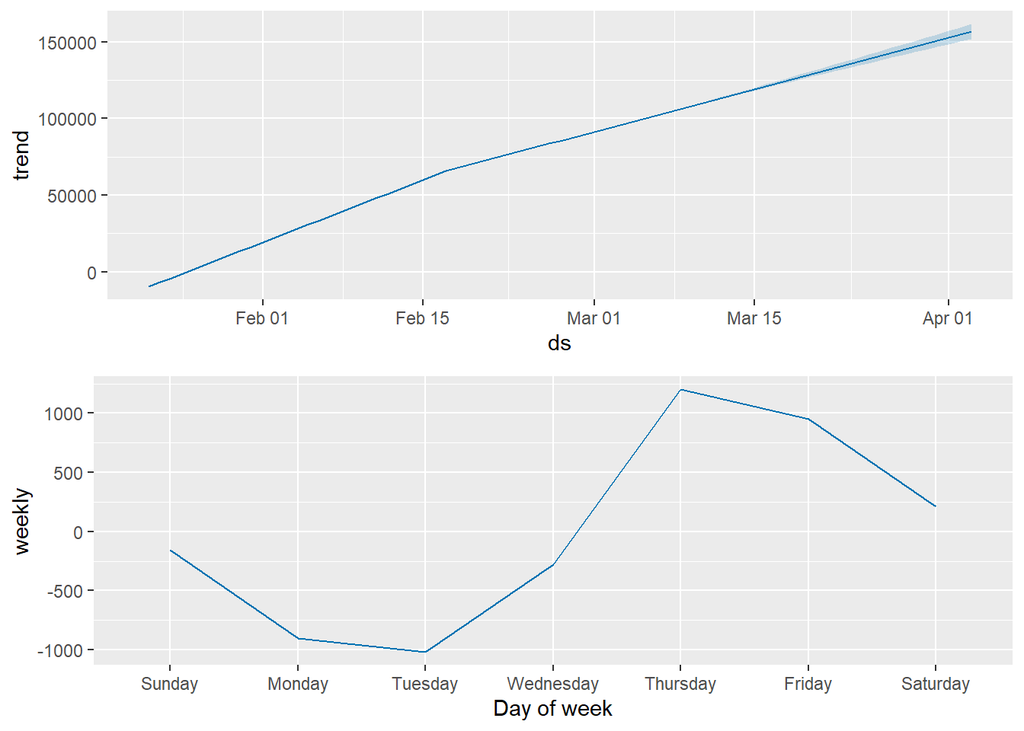

```r
prophet_plot_components(m, forecast)
```

# Kesimpulan

Dari data yang telah diolah pada laporan ini, hasilnya menunjukkan bahwa COVID-19 belum menunjukkan tanda-tanda penurunan yang berarti, bahkan dari hasil prediksi tampak trend yang semakin naik dalam sebulan ke depan. Setiap negara haruslah memiliki concern dan aksi nyata yang dapat mengurangi penyebaran virus ini sehingga trend tersebut dapat dipatahkan.